# Project_01

## Project_01

### Business Problem: Could we be able to predict whether or not the number of orders for a SKU will crash in the future?

- Define 'Crashing': If in the last 10 weeks a SKU's weekly avg number of orders decreases by more than 15% when compared to its average from the 70 weeks, it will be called a crasher.
- Create different statistics for SKUs to be used as parameters to train various classifier algorithims
- Run classifiers on train/test data and evaluate their effectiveness

### Imports

```python
import pandas as pd
import numpy as np
import matplotlib.pyplot as plt
import seaborn as sns
import statsmodels.api as sm
import statsmodels.formula.api as smf
from sklearn.model_selection import train_test_split
from sklearn import metrics
from sklearn.ensemble import RandomForestClassifier
from sklearn.tree import DecisionTreeClassifier
from sklearn.model_selection import cross_val_score
```

### Defining Data Extraction Methods

```python
def add_date_cols(baskets):
    baskets['datetime'] = pd.to_datetime(baskets['placed_at'])
    baskets['year'] = baskets["datetime"].dt.year
    baskets['month'] = baskets["datetime"].dt.month
    baskets['date'] = baskets["datetime"].dt.date
    baskets['day'] = baskets["datetime"].dt.day
    baskets['hour'] = baskets["datetime"].dt.hour
    baskets['weekday'] = baskets["datetime"].dt.weekday
    baskets['year_month'] = baskets["datetime"].apply(lambda t: t.strftime("%Y-%m"))
    baskets['month_num'] = (baskets['year'] - 2021) * 12 + baskets['month']
    baskets['year_week'] = baskets["datetime"].apply(lambda t: t.strftime("%Y-%W")) # this makes the beginning of Jan 2022 as week 2022-00 , not 2022-52
    baskets['week_num'] = baskets["datetime"].apply(lambda t: int(t.strftime("%W")))
    baskets['iso_week_num'] = baskets["datetime"].dt.isocalendar().week # this returns week number 52 for Jan 1, 2021, not 0 which is what we want
    baskets['cum_week_num'] = (baskets['year'] - 2021) * 52 + baskets['week_num']
    return baskets
```

```python
def get_sku_attributes(baskets):
    sku_attributes = baskets.groupby(['sku_id']).agg(
        total_spent = ('spent', 'sum'),
        num_orders = ('order_id', 'nunique'),
        num_merchants = ('merchant_id', 'nunique'),
        first_month = ('month_num', 'min'),
        last_month = ('month_num', 'max'),
        num_months = ('month_num', 'nunique'),
        first_week = ('week_num', 'min'),
        last_week = ('week_num', 'max'),
        num_weeks = ('week_num', 'nunique'),
        num_days = ('date', 'nunique'),
        spent_min = ('spent', 'min'),
        spent_max = ('spent', 'max'),
        spent_std = ('spent', 'std')
    ).reset_index()
    sku_attributes['spent_range'] = sku_attributes['spent_max']-sku_attributes['spent_min']
    sku_attributes['avg_spent_per_order'] = sku_attributes.total_spent / sku_attributes.num_orders
    sku_attributes['spent_spread'] = sku_attributes['spent_range']/sku_attributes['avg_spent_per_order']
    sku_attributes['tenure_month'] = sku_attributes.last_month - sku_attributes.first_month +1
    return sku_attributes
```

- These sku_attributes will be used later as predictors for if a sku will crash or not

```python
def get_skus_by_week(baskets):
    skus_by_week = baskets.groupby(['sku_id','year_week']).agg(
        year = ('year','median'),
        week = ('week_num','median'),
        avg_price_by_week = ('price','mean'),
        num_order_by_week = ('order_id', 'nunique'),
        num_merchants_by_week = ('merchant_id', 'nunique'),
        total_spent_by_week = ('spent', 'sum'),
    ).reset_index()
    return skus_by_week
```

```python
baskets = pd.read_csv('./AwanTunai_transaction_data.csv')
baskets = add_date_cols(baskets)
baskets["spent"] = baskets["qty"] * baskets["price"] # column wide multiplication
sku_week = get_skus_by_week(baskets)
```

```python
sku_attrib = get_sku_attributes(baskets)
sku_attrib
```

|  | sku_id | total_spent | num_orders | num_merchants | first_month | last_month | num_months | first_week | last_week | num_weeks | num_days | spent_min | spent_max | spent_std | spent_range | avg_spent_per_order | spent_spread | tenure_month |
| --- | --- | --- | --- | --- | --- | --- | --- | --- | --- | --- | --- | --- | --- | --- | --- | --- | --- | --- |
| 0 | 1 | 410000.0 | 3 | 1 | 6 | 6 | 1 | 24 | 24 | 1 | 3 | 102500.0 | 205000.0 | 59178.402592 | 102500.0 | 136666.666667 | 0.750000 | 1 |
| 1 | 2 | 63000.0 | 4 | 1 | 6 | 6 | 1 | 24 | 24 | 1 | 3 | 7000.0 | 21000.0 | 6701.989754 | 14000.0 | 15750.000000 | 0.888889 | 1 |
| 2 | 3 | 405000.0 | 3 | 3 | 6 | 6 | 1 | 24 | 24 | 1 | 3 | 135000.0 | 135000.0 | 0.000000 | 0.0 | 135000.000000 | 0.000000 | 1 |
| 3 | 4 | 2192000.0 | 12 | 4 | 6 | 6 | 1 | 24 | 24 | 1 | 3 | 129000.0 | 258000.0 | 66323.358470 | 129000.0 | 182666.666667 | 0.706204 | 1 |
| 4 | 5 | 2222000.0 | 7 | 5 | 6 | 6 | 1 | 24 | 24 | 1 | 3 | 246000.0 | 495000.0 | 121305.546923 | 249000.0 | 317428.571429 | 0.784428 | 1 |
| ... | ... | ... | ... | ... | ... | ... | ... | ... | ... | ... | ... | ... | ... | ... | ... | ... | ... | ... |
| 1855 | 1856 | 2231000.0 | 36 | 21 | 24 | 24 | 1 | 50 | 52 | 3 | 16 | 50000.0 | 102000.0 | 21436.265814 | 52000.0 | 61972.222222 | 0.839086 | 1 |
| 1856 | 1857 | 2253000.0 | 9 | 6 | 24 | 24 | 1 | 50 | 52 | 3 | 9 | 247000.0 | 253000.0 | 3162.277660 | 6000.0 | 250333.333333 | 0.023968 | 1 |
| 1857 | 1858 | 1111500.0 | 13 | 8 | 24 | 24 | 1 | 50 | 52 | 3 | 12 | 60000.0 | 125000.0 | 25946.258561 | 65000.0 | 85500.000000 | 0.760234 | 1 |
| 1858 | 1859 | 1666000.0 | 7 | 6 | 24 | 24 | 1 | 51 | 52 | 2 | 5 | 238000.0 | 238000.0 | 0.000000 | 0.0 | 238000.000000 | 0.000000 | 1 |
| 1859 | 1860 | 216000.0 | 5 | 4 | 24 | 24 | 1 | 51 | 52 | 2 | 3 | 36000.0 | 72000.0 | 16099.689438 | 36000.0 | 43200.000000 | 0.833333 | 1 |

1860 rows × 18 columns

```python
sku_attrib.num_weeks.describe()
```

```
count    1860.000000
mean       25.589785
std        18.319647
min         1.000000
25%         9.000000
50%        17.000000
75%        46.000000
max        53.000000
Name: num_weeks, dtype: float64
```

- most skus occur in many different weeks, however, 25% appear in less than 10. Perhaps the analysis would be most meaningful if these skus were trimmed off of the data set at a later time

```python
sku_week
```

|  | sku_id | year_week | year | week | avg_price_by_week | num_order_by_week | num_merchants_by_week | total_spent_by_week |
| --- | --- | --- | --- | --- | --- | --- | --- | --- |
| 0 | 1 | 2021-24 | 2021.0 | 24.0 | 20500.000000 | 3 | 1 | 410000.0 |
| 1 | 2 | 2021-24 | 2021.0 | 24.0 | 7000.000000 | 4 | 1 | 63000.0 |
| 2 | 3 | 2021-24 | 2021.0 | 24.0 | 135000.000000 | 3 | 3 | 405000.0 |
| 3 | 4 | 2021-24 | 2021.0 | 24.0 | 128958.333333 | 12 | 4 | 2192000.0 |
| 4 | 5 | 2021-24 | 2021.0 | 24.0 | 246714.285714 | 7 | 5 | 2222000.0 |
| ... | ... | ... | ... | ... | ... | ... | ... | ... |
| 54339 | 1858 | 2022-52 | 2022.0 | 52.0 | 12500.000000 | 2 | 2 | 125000.0 |
| 54340 | 1859 | 2022-51 | 2022.0 | 51.0 | 238000.000000 | 4 | 4 | 952000.0 |
| 54341 | 1859 | 2022-52 | 2022.0 | 52.0 | 238000.000000 | 3 | 2 | 714000.0 |
| 54342 | 1860 | 2022-51 | 2022.0 | 51.0 | 36000.000000 | 2 | 2 | 108000.0 |
| 54343 | 1860 | 2022-52 | 2022.0 | 52.0 | 36000.000000 | 3 | 3 | 108000.0 |

54344 rows × 8 columns

```python
sku_week['week_num']=(((sku_week['year']-2021)*52)+sku_week['week'])
## Keeping track of the cummulative week num, without resetting each year
sku_week
```

|  | sku_id | year_week | year | week | avg_price_by_week | num_order_by_week | num_merchants_by_week | total_spent_by_week | week_num |
| --- | --- | --- | --- | --- | --- | --- | --- | --- | --- |
| 0 | 1 | 2021-24 | 2021.0 | 24.0 | 20500.000000 | 3 | 1 | 410000.0 | 24.0 |
| 1 | 2 | 2021-24 | 2021.0 | 24.0 | 7000.000000 | 4 | 1 | 63000.0 | 24.0 |
| 2 | 3 | 2021-24 | 2021.0 | 24.0 | 135000.000000 | 3 | 3 | 405000.0 | 24.0 |
| 3 | 4 | 2021-24 | 2021.0 | 24.0 | 128958.333333 | 12 | 4 | 2192000.0 | 24.0 |
| 4 | 5 | 2021-24 | 2021.0 | 24.0 | 246714.285714 | 7 | 5 | 2222000.0 | 24.0 |
| ... | ... | ... | ... | ... | ... | ... | ... | ... | ... |
| 54339 | 1858 | 2022-52 | 2022.0 | 52.0 | 12500.000000 | 2 | 2 | 125000.0 | 104.0 |
| 54340 | 1859 | 2022-51 | 2022.0 | 51.0 | 238000.000000 | 4 | 4 | 952000.0 | 103.0 |
| 54341 | 1859 | 2022-52 | 2022.0 | 52.0 | 238000.000000 | 3 | 2 | 714000.0 | 104.0 |
| 54342 | 1860 | 2022-51 | 2022.0 | 51.0 | 36000.000000 | 2 | 2 | 108000.0 | 103.0 |
| 54343 | 1860 | 2022-52 | 2022.0 | 52.0 | 36000.000000 | 3 | 3 | 108000.0 | 104.0 |

54344 rows × 9 columns

```python
%matplotlib inline
import matplotlib.pyplot as plt
def lin_regplot(X, y, model):
    plt.scatter(X, y, c='blue')
    plt.plot(X, model.predict(X), color='red')
    return
```

```python
sku_attrib['first70_avg']=sku_week.query('week_num<93').groupby(['sku_id']).agg(avg_order_by_week=('num_order_by_week','mean'))
sku_attrib['last10_avg']=sku_week.query('week_num>=93').groupby(['sku_id']).agg(avg_order_by_week=('num_order_by_week','mean')).fillna(value = 0)
sku_attrib['crash']=(sku_attrib['last10_avg']<(sku_attrib['first70_avg']*0.85)).astype(int)
sku_attrib
```

|  | sku_id | total_spent | num_orders | num_merchants | first_month | last_month | num_months | first_week | last_week | num_weeks | ... | spent_min | spent_max | spent_std | spent_range | avg_spent_per_order | spent_spread | tenure_month | first70_avg | last10_avg | crash |
| --- | --- | --- | --- | --- | --- | --- | --- | --- | --- | --- | --- | --- | --- | --- | --- | --- | --- | --- | --- | --- | --- |
| 0 | 1 | 410000.0 | 3 | 1 | 6 | 6 | 1 | 24 | 24 | 1 | ... | 102500.0 | 205000.0 | 59178.402592 | 102500.0 | 136666.666667 | 0.750000 | 1 | NaN | NaN | 0 |
| 1 | 2 | 63000.0 | 4 | 1 | 6 | 6 | 1 | 24 | 24 | 1 | ... | 7000.0 | 21000.0 | 6701.989754 | 14000.0 | 15750.000000 | 0.888889 | 1 | 3.0 | NaN | 0 |
| 2 | 3 | 405000.0 | 3 | 3 | 6 | 6 | 1 | 24 | 24 | 1 | ... | 135000.0 | 135000.0 | 0.000000 | 0.0 | 135000.000000 | 0.000000 | 1 | 4.0 | NaN | 0 |
| 3 | 4 | 2192000.0 | 12 | 4 | 6 | 6 | 1 | 24 | 24 | 1 | ... | 129000.0 | 258000.0 | 66323.358470 | 129000.0 | 182666.666667 | 0.706204 | 1 | 3.0 | NaN | 0 |
| 4 | 5 | 2222000.0 | 7 | 5 | 6 | 6 | 1 | 24 | 24 | 1 | ... | 246000.0 | 495000.0 | 121305.546923 | 249000.0 | 317428.571429 | 0.784428 | 1 | 12.0 | NaN | 0 |
| ... | ... | ... | ... | ... | ... | ... | ... | ... | ... | ... | ... | ... | ... | ... | ... | ... | ... | ... | ... | ... | ... |
| 1855 | 1856 | 2231000.0 | 36 | 21 | 24 | 24 | 1 | 50 | 52 | 3 | ... | 50000.0 | 102000.0 | 21436.265814 | 52000.0 | 61972.222222 | 0.839086 | 1 | NaN | 3.000000 | 0 |
| 1856 | 1857 | 2253000.0 | 9 | 6 | 24 | 24 | 1 | 50 | 52 | 3 | ... | 247000.0 | 253000.0 | 3162.277660 | 6000.0 | 250333.333333 | 0.023968 | 1 | NaN | 12.000000 | 0 |
| 1857 | 1858 | 1111500.0 | 13 | 8 | 24 | 24 | 1 | 50 | 52 | 3 | ... | 60000.0 | 125000.0 | 25946.258561 | 65000.0 | 85500.000000 | 0.760234 | 1 | NaN | 3.000000 | 0 |
| 1858 | 1859 | 1666000.0 | 7 | 6 | 24 | 24 | 1 | 51 | 52 | 2 | ... | 238000.0 | 238000.0 | 0.000000 | 0.0 | 238000.000000 | 0.000000 | 1 | NaN | 4.333333 | 0 |
| 1859 | 1860 | 216000.0 | 5 | 4 | 24 | 24 | 1 | 51 | 52 | 2 | ... | 36000.0 | 72000.0 | 16099.689438 | 36000.0 | 43200.000000 | 0.833333 | 1 | NaN | 3.500000 | 0 |

1860 rows × 21 columns

- Defining which SKU's are crashers: If the average of their weekly number of orders over the last ten weeks is less than 85% of the average of their weekly number orders from the first 70 weeks,they are considered a churner

```python
sku_attrib['crash'].value_counts()
```

```
0    1626
1     234
Name: crash, dtype: int64
```

- Around 12% of the SKU's are considered crashers

```python
sku_week=sku_week.query('week_num<93')
```

- Trimming the data set so only the test data values are considered when computing beta values for later analysis

```python
mlist = sku_week['sku_id'].unique()

orders = pd.DataFrame(data = np.zeros(mlist.shape[0]),columns=['beta_order'],index=mlist)

for sku_id, beta_order in orders.iterrows():
    temp = sku_week[sku_week['sku_id'] == sku_id]

    model = smf.ols(formula = 'week_num~num_order_by_week',data=temp).fit()
    orders.loc[sku_id,'beta_order']=model.params['num_order_by_week']
orders
```

|  | beta_order |
| --- | --- |
| 1 | 7.200000 |
| 2 | 5.647059 |
| 3 | 7.200000 |
| 4 | 1.986207 |
| 5 | 3.360000 |
| ... | ... |
| 1836 | -0.750000 |
| 1837 | 44.500000 |
| 1838 | 44.750000 |
| 1839 | 0.750000 |
| 1840 | 45.500000 |

1837 rows × 1 columns

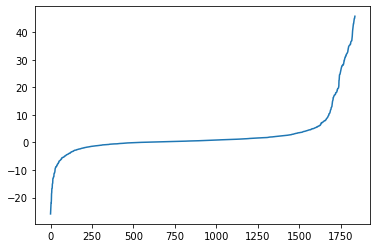

```python
orders.beta_order.sort_values().reset_index(drop=True).plot()
```

```python
orders.beta_order.describe()
```

```
count    1837.000000
mean        2.618923
std         8.475283
min       -25.900000
25%        -0.200000
50%         0.664513
75%         2.267023
max        45.750000
Name: beta_order, dtype: float64
```

```python
orders.sort_values(by = 'beta_order', ascending = True)
```

|  | beta_order |
| --- | --- |
| 1334 | -25.900000 |
| 1091 | -24.500000 |
| 836 | -22.222222 |
| 1607 | -22.000000 |
| 1749 | -22.000000 |
| ... | ... |
| 1838 | 44.750000 |
| 1815 | 45.000000 |
| 1832 | 45.000000 |
| 1840 | 45.500000 |
| 1834 | 45.750000 |

1837 rows × 1 columns

```python
beta_orders = orders['beta_order']
```

```python
orders.reset_index()
orders
```

|  | beta_order |
| --- | --- |
| 1 | 7.200000 |
| 2 | 5.647059 |
| 3 | 7.200000 |
| 4 | 1.986207 |
| 5 | 3.360000 |
| ... | ... |
| 1836 | -0.750000 |
| 1837 | 44.500000 |
| 1838 | 44.750000 |
| 1839 | 0.750000 |
| 1840 | 45.500000 |

1837 rows × 1 columns

```python
mlist = sku_week['sku_id'].unique()

prices = pd.DataFrame(data = np.zeros(mlist.shape[0]),columns=['beta_price'],index=mlist)

for sku_id, beta_price in prices.iterrows():
    temp = sku_week[sku_week['sku_id'] == sku_id]

    model = smf.ols(formula = 'week_num~avg_price_by_week',data=temp).fit()
    prices.loc[sku_id,'beta_price']=model.params['avg_price_by_week']
prices
```

|  | beta_price |
| --- | --- |
| 1 | 0.001171 |
| 2 | 0.003429 |
| 3 | 0.000178 |
| 4 | 0.000186 |
| 5 | 0.000097 |
| ... | ... |
| 1836 | 0.004167 |
| 1837 | 0.001060 |
| 1838 | 0.000895 |
| 1839 | 0.000750 |
| 1840 | 0.010706 |

1837 rows × 1 columns

```python
sku_attrib = sku_attrib.set_index('sku_id')

sku_attrib
```

| sku_id | total_spent | num_orders | num_merchants | first_month | last_month | num_months | first_week | last_week | num_weeks | num_days | spent_min | spent_max | spent_std | spent_range | avg_spent_per_order | spent_spread | tenure_month | first70_avg | last10_avg | crash |
| --- | --- | --- | --- | --- | --- | --- | --- | --- | --- | --- | --- | --- | --- | --- | --- | --- | --- | --- | --- | --- |
| 1 | 410000.0 | 3 | 1 | 6 | 6 | 1 | 24 | 24 | 1 | 3 | 102500.0 | 205000.0 | 59178.402592 | 102500.0 | 136666.666667 | 0.750000 | 1 | NaN | NaN | 0 |
| 2 | 63000.0 | 4 | 1 | 6 | 6 | 1 | 24 | 24 | 1 | 3 | 7000.0 | 21000.0 | 6701.989754 | 14000.0 | 15750.000000 | 0.888889 | 1 | 3.0 | NaN | 0 |
| 3 | 405000.0 | 3 | 3 | 6 | 6 | 1 | 24 | 24 | 1 | 3 | 135000.0 | 135000.0 | 0.000000 | 0.0 | 135000.000000 | 0.000000 | 1 | 4.0 | NaN | 0 |
| 4 | 2192000.0 | 12 | 4 | 6 | 6 | 1 | 24 | 24 | 1 | 3 | 129000.0 | 258000.0 | 66323.358470 | 129000.0 | 182666.666667 | 0.706204 | 1 | 3.0 | NaN | 0 |
| 5 | 2222000.0 | 7 | 5 | 6 | 6 | 1 | 24 | 24 | 1 | 3 | 246000.0 | 495000.0 | 121305.546923 | 249000.0 | 317428.571429 | 0.784428 | 1 | 12.0 | NaN | 0 |
| ... | ... | ... | ... | ... | ... | ... | ... | ... | ... | ... | ... | ... | ... | ... | ... | ... | ... | ... | ... | ... |
| 1856 | 2231000.0 | 36 | 21 | 24 | 24 | 1 | 50 | 52 | 3 | 16 | 50000.0 | 102000.0 | 21436.265814 | 52000.0 | 61972.222222 | 0.839086 | 1 | NaN | 3.000000 | 0 |
| 1857 | 2253000.0 | 9 | 6 | 24 | 24 | 1 | 50 | 52 | 3 | 9 | 247000.0 | 253000.0 | 3162.277660 | 6000.0 | 250333.333333 | 0.023968 | 1 | NaN | 12.000000 | 0 |
| 1858 | 1111500.0 | 13 | 8 | 24 | 24 | 1 | 50 | 52 | 3 | 12 | 60000.0 | 125000.0 | 25946.258561 | 65000.0 | 85500.000000 | 0.760234 | 1 | NaN | 3.000000 | 0 |
| 1859 | 1666000.0 | 7 | 6 | 24 | 24 | 1 | 51 | 52 | 2 | 5 | 238000.0 | 238000.0 | 0.000000 | 0.0 | 238000.000000 | 0.000000 | 1 | NaN | 4.333333 | 0 |
| 1860 | 216000.0 | 5 | 4 | 24 | 24 | 1 | 51 | 52 | 2 | 3 | 36000.0 | 72000.0 | 16099.689438 | 36000.0 | 43200.000000 | 0.833333 | 1 | NaN | 3.500000 | 0 |

1860 rows × 20 columns

```python
sku_attrib['beta_order'] = orders['beta_order']
sku_attrib['price_beta'] = prices['beta_price']
sku_attrib
```

| sku_id | total_spent | num_orders | num_merchants | first_month | last_month | num_months | first_week | last_week | num_weeks | num_days | ... | spent_std | spent_range | avg_spent_per_order | spent_spread | tenure_month | first70_avg | last10_avg | crash | beta_order | price_beta |
| --- | --- | --- | --- | --- | --- | --- | --- | --- | --- | --- | --- | --- | --- | --- | --- | --- | --- | --- | --- | --- | --- |
| 1 | 410000.0 | 3 | 1 | 6 | 6 | 1 | 24 | 24 | 1 | 3 | ... | 59178.402592 | 102500.0 | 136666.666667 | 0.750000 | 1 | NaN | NaN | 0 | 7.200000 | 0.001171 |
| 2 | 63000.0 | 4 | 1 | 6 | 6 | 1 | 24 | 24 | 1 | 3 | ... | 6701.989754 | 14000.0 | 15750.000000 | 0.888889 | 1 | 3.0 | NaN | 0 | 5.647059 | 0.003429 |
| 3 | 405000.0 | 3 | 3 | 6 | 6 | 1 | 24 | 24 | 1 | 3 | ... | 0.000000 | 0.0 | 135000.000000 | 0.000000 | 1 | 4.0 | NaN | 0 | 7.200000 | 0.000178 |
| 4 | 2192000.0 | 12 | 4 | 6 | 6 | 1 | 24 | 24 | 1 | 3 | ... | 66323.358470 | 129000.0 | 182666.666667 | 0.706204 | 1 | 3.0 | NaN | 0 | 1.986207 | 0.000186 |
| 5 | 2222000.0 | 7 | 5 | 6 | 6 | 1 | 24 | 24 | 1 | 3 | ... | 121305.546923 | 249000.0 | 317428.571429 | 0.784428 | 1 | 12.0 | NaN | 0 | 3.360000 | 0.000097 |
| ... | ... | ... | ... | ... | ... | ... | ... | ... | ... | ... | ... | ... | ... | ... | ... | ... | ... | ... | ... | ... | ... |
| 1856 | 2231000.0 | 36 | 21 | 24 | 24 | 1 | 50 | 52 | 3 | 16 | ... | 21436.265814 | 52000.0 | 61972.222222 | 0.839086 | 1 | NaN | 3.000000 | 0 | NaN | NaN |
| 1857 | 2253000.0 | 9 | 6 | 24 | 24 | 1 | 50 | 52 | 3 | 9 | ... | 3162.277660 | 6000.0 | 250333.333333 | 0.023968 | 1 | NaN | 12.000000 | 0 | NaN | NaN |
| 1858 | 1111500.0 | 13 | 8 | 24 | 24 | 1 | 50 | 52 | 3 | 12 | ... | 25946.258561 | 65000.0 | 85500.000000 | 0.760234 | 1 | NaN | 3.000000 | 0 | NaN | NaN |
| 1859 | 1666000.0 | 7 | 6 | 24 | 24 | 1 | 51 | 52 | 2 | 5 | ... | 0.000000 | 0.0 | 238000.000000 | 0.000000 | 1 | NaN | 4.333333 | 0 | NaN | NaN |
| 1860 | 216000.0 | 5 | 4 | 24 | 24 | 1 | 51 | 52 | 2 | 3 | ... | 16099.689438 | 36000.0 | 43200.000000 | 0.833333 | 1 | NaN | 3.500000 | 0 | NaN | NaN |

1860 rows × 22 columns

```python
sku_attrib = sku_attrib[sku_attrib['num_weeks']>=10]
sku_attrib
```

| sku_id | total_spent | num_orders | num_merchants | first_month | last_month | num_months | first_week | last_week | num_weeks | num_days | ... | spent_std | spent_range | avg_spent_per_order | spent_spread | tenure_month | first70_avg | last10_avg | crash | beta_order | price_beta |
| --- | --- | --- | --- | --- | --- | --- | --- | --- | --- | --- | --- | --- | --- | --- | --- | --- | --- | --- | --- | --- | --- |
| 33 | 9525000.0 | 69 | 26 | 6 | 10 | 5 | 25 | 41 | 15 | 39 | ... | 60791.636611 | 164000.0 | 138043.478261 | 1.188031 | 5 | 3.000000 | NaN | 0 | 0.330381 | 0.007158 |
| 35 | 1794000.0 | 30 | 16 | 6 | 10 | 5 | 26 | 41 | 11 | 23 | ... | 79046.647075 | 344000.0 | 59800.000000 | 5.752508 | 5 | 1.800000 | NaN | 0 | 0.895833 | 0.000123 |
| 36 | 26023000.0 | 346 | 75 | 6 | 10 | 5 | 25 | 41 | 17 | 90 | ... | 80401.593435 | 580000.0 | 75210.982659 | 7.711640 | 5 | 2.727273 | NaN | 0 | 0.209058 | 0.003697 |
| 38 | 10010000.0 | 144 | 36 | 6 | 10 | 5 | 25 | 41 | 17 | 72 | ... | 74312.888520 | 344000.0 | 69513.888889 | 4.948651 | 5 | 1.000000 | NaN | 0 | 0.551351 | -0.021023 |
| 39 | 1904000.0 | 34 | 17 | 6 | 10 | 5 | 25 | 41 | 17 | 26 | ... | 60904.918446 | 233500.0 | 56000.000000 | 4.169643 | 5 | 8.470588 | NaN | 0 | 1.442308 | 0.012636 |
| ... | ... | ... | ... | ... | ... | ... | ... | ... | ... | ... | ... | ... | ... | ... | ... | ... | ... | ... | ... | ... | ... |
| 1836 | 2008800.0 | 21 | 10 | 21 | 24 | 4 | 37 | 52 | 13 | 18 | ... | 23235.244165 | 64800.0 | 95657.142857 | 0.677419 | 4 | 2.000000 | 1.333333 | 1 | -0.750000 | 0.004167 |
| 1839 | 17866000.0 | 86 | 20 | 21 | 24 | 4 | 38 | 52 | 15 | 51 | ... | 30774.965397 | 205000.0 | 207744.186047 | 0.986791 | 4 | 1.000000 | 1.250000 | 0 | 0.750000 | 0.000750 |
| 1842 | 22333000.0 | 98 | 34 | 22 | 24 | 3 | 42 | 52 | 11 | 30 | ... | 193829.443714 | 1457000.0 | 227887.755102 | 6.393498 | 3 | NaN | 1.333333 | 0 | NaN | NaN |
| 1843 | 14809500.0 | 94 | 26 | 22 | 24 | 3 | 41 | 52 | 12 | 50 | ... | 31809.418125 | 162500.0 | 157547.872340 | 1.031433 | 3 | NaN | 8.909091 | 0 | NaN | NaN |
| 1844 | 19921000.0 | 65 | 16 | 22 | 24 | 3 | 43 | 52 | 10 | 28 | ... | 293502.933742 | 1447000.0 | 306476.923077 | 4.721400 | 3 | NaN | 7.833333 | 0 | NaN | NaN |

1386 rows × 22 columns

```python
sku_attrib = sku_attrib.reset_index()
sku_attrib
```

|  | sku_id | total_spent | num_orders | num_merchants | first_month | last_month | num_months | first_week | last_week | num_weeks | ... | spent_std | spent_range | avg_spent_per_order | spent_spread | tenure_month | first70_avg | last10_avg | crash | beta_order | price_beta |
| --- | --- | --- | --- | --- | --- | --- | --- | --- | --- | --- | --- | --- | --- | --- | --- | --- | --- | --- | --- | --- | --- |
| 0 | 33 | 9525000.0 | 69 | 26 | 6 | 10 | 5 | 25 | 41 | 15 | ... | 60791.636611 | 164000.0 | 138043.478261 | 1.188031 | 5 | 3.000000 | NaN | 0 | 0.330381 | 0.007158 |
| 1 | 35 | 1794000.0 | 30 | 16 | 6 | 10 | 5 | 26 | 41 | 11 | ... | 79046.647075 | 344000.0 | 59800.000000 | 5.752508 | 5 | 1.800000 | NaN | 0 | 0.895833 | 0.000123 |
| 2 | 36 | 26023000.0 | 346 | 75 | 6 | 10 | 5 | 25 | 41 | 17 | ... | 80401.593435 | 580000.0 | 75210.982659 | 7.711640 | 5 | 2.727273 | NaN | 0 | 0.209058 | 0.003697 |
| 3 | 38 | 10010000.0 | 144 | 36 | 6 | 10 | 5 | 25 | 41 | 17 | ... | 74312.888520 | 344000.0 | 69513.888889 | 4.948651 | 5 | 1.000000 | NaN | 0 | 0.551351 | -0.021023 |
| 4 | 39 | 1904000.0 | 34 | 17 | 6 | 10 | 5 | 25 | 41 | 17 | ... | 60904.918446 | 233500.0 | 56000.000000 | 4.169643 | 5 | 8.470588 | NaN | 0 | 1.442308 | 0.012636 |
| ... | ... | ... | ... | ... | ... | ... | ... | ... | ... | ... | ... | ... | ... | ... | ... | ... | ... | ... | ... | ... | ... |
| 1381 | 1836 | 2008800.0 | 21 | 10 | 21 | 24 | 4 | 37 | 52 | 13 | ... | 23235.244165 | 64800.0 | 95657.142857 | 0.677419 | 4 | 2.000000 | 1.333333 | 1 | -0.750000 | 0.004167 |
| 1382 | 1839 | 17866000.0 | 86 | 20 | 21 | 24 | 4 | 38 | 52 | 15 | ... | 30774.965397 | 205000.0 | 207744.186047 | 0.986791 | 4 | 1.000000 | 1.250000 | 0 | 0.750000 | 0.000750 |
| 1383 | 1842 | 22333000.0 | 98 | 34 | 22 | 24 | 3 | 42 | 52 | 11 | ... | 193829.443714 | 1457000.0 | 227887.755102 | 6.393498 | 3 | NaN | 1.333333 | 0 | NaN | NaN |
| 1384 | 1843 | 14809500.0 | 94 | 26 | 22 | 24 | 3 | 41 | 52 | 12 | ... | 31809.418125 | 162500.0 | 157547.872340 | 1.031433 | 3 | NaN | 8.909091 | 0 | NaN | NaN |
| 1385 | 1844 | 19921000.0 | 65 | 16 | 22 | 24 | 3 | 43 | 52 | 10 | ... | 293502.933742 | 1447000.0 | 306476.923077 | 4.721400 | 3 | NaN | 7.833333 | 0 | NaN | NaN |

1386 rows × 23 columns

```python
sku_attrib.set_index('sku_id',inplace = True)
```

```python
sku_week
```

|  | sku_id | year_week | year | week | avg_price_by_week | num_order_by_week | num_merchants_by_week | total_spent_by_week | week_num |
| --- | --- | --- | --- | --- | --- | --- | --- | --- | --- |
| 0 | 1 | 2021-24 | 2021.0 | 24.0 | 20500.000000 | 3 | 1 | 410000.0 | 24.0 |
| 1 | 2 | 2021-24 | 2021.0 | 24.0 | 7000.000000 | 4 | 1 | 63000.0 | 24.0 |
| 2 | 3 | 2021-24 | 2021.0 | 24.0 | 135000.000000 | 3 | 3 | 405000.0 | 24.0 |
| 3 | 4 | 2021-24 | 2021.0 | 24.0 | 128958.333333 | 12 | 4 | 2192000.0 | 24.0 |
| 4 | 5 | 2021-24 | 2021.0 | 24.0 | 246714.285714 | 7 | 5 | 2222000.0 | 24.0 |
| ... | ... | ... | ... | ... | ... | ... | ... | ... | ... |
| 54229 | 1839 | 2022-38 | 2022.0 | 38.0 | 201000.000000 | 2 | 2 | 402000.0 | 90.0 |
| 54230 | 1839 | 2022-39 | 2022.0 | 39.0 | 201000.000000 | 2 | 2 | 402000.0 | 91.0 |
| 54231 | 1839 | 2022-40 | 2022.0 | 40.0 | 203000.000000 | 4 | 4 | 812000.0 | 92.0 |
| 54244 | 1840 | 2022-38 | 2022.0 | 38.0 | 8500.000000 | 1 | 1 | 42500.0 | 90.0 |
| 54245 | 1840 | 2022-40 | 2022.0 | 40.0 | 8500.000000 | 1 | 1 | 25500.0 | 92.0 |

45184 rows × 9 columns

```python
sku_attrib.dropna(inplace = True)
```

```python
sku_attrib
```

| sku_id | total_spent | num_orders | num_merchants | first_month | last_month | num_months | first_week | last_week | num_weeks | num_days | ... | spent_std | spent_range | avg_spent_per_order | spent_spread | tenure_month | first70_avg | last10_avg | crash | beta_order | price_beta |
| --- | --- | --- | --- | --- | --- | --- | --- | --- | --- | --- | --- | --- | --- | --- | --- | --- | --- | --- | --- | --- | --- |
| 656 | 5308000.0 | 46 | 14 | 10 | 24 | 15 | 1 | 52 | 33 | 43 | ... | 16369.997300 | 112000.0 | 115391.304348 | 0.970610 | 15 | 1.571429 | 2.571429 | 0 | 1.650327 | 0.009290 |
| 657 | 10077500.0 | 74 | 25 | 10 | 24 | 15 | 0 | 52 | 40 | 66 | ... | 65587.104809 | 502500.0 | 136182.432432 | 3.689903 | 15 | 1.344828 | 1.166667 | 0 | -2.442010 | 0.004344 |
| 658 | 7303000.0 | 301 | 58 | 10 | 24 | 15 | 1 | 52 | 52 | 213 | ... | 12232.097910 | 53000.0 | 24262.458472 | 2.184445 | 15 | 1.628571 | 1.888889 | 0 | -1.507459 | 0.035382 |
| 659 | 252822500.0 | 1412 | 179 | 10 | 24 | 15 | 0 | 52 | 53 | 361 | ... | 149988.719914 | 2242000.0 | 179052.762040 | 12.521449 | 15 | 5.039216 | 3.666667 | 1 | 0.620998 | 0.003153 |
| 660 | 31843500.0 | 1206 | 84 | 10 | 24 | 15 | 0 | 52 | 53 | 361 | ... | 15199.317205 | 95000.0 | 26404.228856 | 3.597909 | 15 | 22.301887 | 19.166667 | 0 | 0.691037 | 0.026821 |
| ... | ... | ... | ... | ... | ... | ... | ... | ... | ... | ... | ... | ... | ... | ... | ... | ... | ... | ... | ... | ... | ... |
| 1830 | 22686000.0 | 83 | 20 | 21 | 24 | 4 | 37 | 52 | 16 | 50 | ... | 77365.557414 | 511000.0 | 273325.301205 | 1.869567 | 4 | 12.000000 | 1.500000 | 1 | 0.222222 | 0.000355 |
| 1831 | 5612000.0 | 46 | 17 | 21 | 24 | 4 | 37 | 52 | 14 | 31 | ... | 22070.342091 | 153000.0 | 122000.000000 | 1.254098 | 4 | 3.250000 | 5.833333 | 0 | 1.500000 | 0.003549 |
| 1834 | 2368000.0 | 15 | 8 | 22 | 24 | 3 | 39 | 50 | 11 | 15 | ... | 38213.435683 | 148000.0 | 157866.666667 | 0.937500 | 3 | 2.000000 | 1.000000 | 1 | 45.750000 | 0.000618 |
| 1836 | 2008800.0 | 21 | 10 | 21 | 24 | 4 | 37 | 52 | 13 | 18 | ... | 23235.244165 | 64800.0 | 95657.142857 | 0.677419 | 4 | 2.000000 | 1.333333 | 1 | -0.750000 | 0.004167 |
| 1839 | 17866000.0 | 86 | 20 | 21 | 24 | 4 | 38 | 52 | 15 | 51 | ... | 30774.965397 | 205000.0 | 207744.186047 | 0.986791 | 4 | 1.000000 | 1.250000 | 0 | 0.750000 | 0.000750 |

892 rows × 22 columns

```python
X = sku_attrib[['beta_order','price_beta','num_merchants','num_weeks']]
Y= sku_attrib.crash
```

- Using both beta values, the number of merchants, and the number of weeks as predictor variables

```python
X_train, X_test, y_train, y_test = train_test_split(X,Y, test_size=0.33,random_state=7)
```

```python
from sklearn.neighbors import KNeighborsClassifier
knn = KNeighborsClassifier(p=1)
knn.fit(X_train, y_train)
```

```
KNeighborsClassifier(p=1)
```

```python
y_pred = knn.predict(X_test)
```

```python
metrics.confusion_matrix(y_test,y_pred)
```

```
array([[211,  14],
       [ 62,   8]])
```

- knn algorithim proves innefective at predicting crashers

```python
rf = RandomForestClassifier(max_depth=5, random_state=13)
rf.fit(X_train,y_train)
print(rf.predict(X_test))
```

```
[0 0 0 0 0 0 0 0 1 0 0 0 0 0 0 0 0 0 0 0 0 0 0 0 0 0 0 0 0 0 0 0 0 0 0 0 0
 0 0 0 0 0 0 0 0 0 0 0 0 0 0 0 0 0 0 0 0 0 0 0 0 0 0 0 0 0 0 0 1 0 0 0 0 0
 0 0 0 0 0 0 0 0 0 0 0 0 0 0 0 0 0 0 0 0 0 0 0 0 0 0 0 0 0 0 0 0 0 0 0 0 0
 0 0 0 0 0 0 0 0 0 0 0 0 0 0 0 0 0 0 0 0 0 0 0 0 0 0 0 0 0 0 0 0 0 0 0 0 0
 0 0 0 0 0 0 0 0 0 0 0 0 0 0 1 0 0 0 0 0 0 0 0 0 0 0 0 0 0 0 0 0 0 0 0 0 0
 0 0 0 0 0 0 0 0 0 0 0 0 0 0 0 0 0 0 0 0 0 0 0 0 0 0 0 0 0 0 0 0 0 0 0 0 0
 0 0 0 0 0 0 0 0 0 0 0 0 0 0 0 0 0 0 0 0 0 0 0 0 0 0 0 0 1 0 0 0 0 0 0 0 0
 0 0 0 0 0 0 0 0 0 0 0 0 0 0 0 0 0 0 0 0 0 0 0 0 0 0 0 0 0 0 0 0 0 0 0 0]
```

```python
print(metrics.classification_report(y_test,rf.predict(X_test)))
```

```
              precision    recall  f1-score   support

           0       0.76      0.99      0.86       225
           1       0.25      0.01      0.03        70

    accuracy                           0.76       295
   macro avg       0.51      0.50      0.44       295
weighted avg       0.64      0.76      0.66       295
```

- Random forest also not very effective at predicing crashers

```python
clf = DecisionTreeClassifier()
clf = clf.fit(X_train,y_train)
score = clf.score(X_test,y_test)
cv_score = cross_val_score(clf,X_train,y_train,cv=10)
score,cv_score
```

```
(0.576271186440678,
 array([0.6       , 0.7       , 0.66666667, 0.58333333, 0.7       ,
        0.66666667, 0.63333333, 0.6779661 , 0.66101695, 0.62711864]))
```

```python
metrics.confusion_matrix(y_test,clf.predict(X_test))
```

```
array([[147,  78],
       [ 47,  23]])
```

- Decision Tree classifier more prone to classify as a crasher, but still quite inneffective
- Overall, none of the classifiers were very effective. I think that one way to improve would be do more research into the actual economy behind the dataset and hopefully come away some better predictor parameters. Then, a large number of potential predictor variables could be assembled and put into a multiple regression analysis to evaluate the strength of their correlation with the number of orders a SKU receives. Then, the strongest of these variables could be fed into the classifier algorithims to hopefully develope a better predictor.